# Modelado

Metronhomo

January 14, 2016

En este trabajo utilizamos una base de datos que contiene 74,384 personas. Cada una de las personas tiene variables que hablan acerca de su estabilidad económica, variables relacionadas a la criminalidad de la zona en la que vive y una variable que indica la marginación de la zona en la que vive. Esta base hay 18,746 personas que se convirtieron a crédito en los años 2014 y 2015; el resto de las personas en la base solo tienen cuenta de captación.

Las variables que hablan sobre su estabilidad económica se obtuvieron haciendo resúmenes de sus transacciones, ejemplos de esto son el balance de los 30 días anteriores al surtimiento de su primer crédito o el número de transacciones realizado en el semestre anterior al surtimiento de su primer crédito. Este trabajo busca encontrar un modelo que reproduzca, de la mejor manera posible, la realidad mostrada en la base de datos antes mencionada.

Para lograr lo anterior probamos cuatro modelos: **Regresión Logística, Bosques aleatorios, Gradient Boosting y SVM**. A continuación mostramos los resultados obtenidos:

# Bosques Aleatorios

```
## Confusion Matrix and Statistics
##
##           Reference
## Prediction     0     1
##          0 16659   970
##          1    55  4631
##
##                Accuracy : 0.9541
##                  95% CI : (0.9512, 0.9568)
##     No Information Rate : 0.749
##     P-Value [Acc > NIR] : < 2.2e-16
##
##                   Kappa : 0.8708
##  Mcnemar's Test P-Value : < 2.2e-16
##
##             Sensitivity : 0.9967
##             Specificity : 0.8268
##          Pos Pred Value : 0.9450
##          Neg Pred Value : 0.9883
##              Prevalence : 0.7490
##          Detection Rate : 0.7465
##    Detection Prevalence : 0.7900
##       Balanced Accuracy : 0.9118
##
##        'Positive' Class : 0
##
```

# Gradient Boosting

```
## Confusion Matrix and Statistics
##
##           Reference
## Prediction     0     1
##          0 16606  1099
##          1   108  4502
##
##                Accuracy : 0.9459
##                  95% CI : (0.9429, 0.9488)
##     No Information Rate : 0.749
##     P-Value [Acc > NIR] : < 2.2e-16
##
##                   Kappa : 0.8472
##  Mcnemar's Test P-Value : < 2.2e-16
##
##             Sensitivity : 0.9935
##             Specificity : 0.8038
##          Pos Pred Value : 0.9379
##          Neg Pred Value : 0.9766
##              Prevalence : 0.7490
##          Detection Rate : 0.7442
##    Detection Prevalence : 0.7934
##       Balanced Accuracy : 0.8987
##
##        'Positive' Class : 0
##
```

# Regresión Logística

```
## Confusion Matrix and Statistics
##
##           Reference
## Prediction     0     1
##          0 16491  3619
##          1   223  1982
##
##                Accuracy : 0.8278
##                  95% CI : (0.8228, 0.8328)
##     No Information Rate : 0.749
##     P-Value [Acc > NIR] : < 2.2e-16
##
##                   Kappa : 0.4265
##  Mcnemar's Test P-Value : < 2.2e-16
##
##             Sensitivity : 0.9867
##             Specificity : 0.3539
##          Pos Pred Value : 0.8200
##          Neg Pred Value : 0.8989
##              Prevalence : 0.7490
##          Detection Rate : 0.7390
##    Detection Prevalence : 0.9012
##       Balanced Accuracy : 0.6703
##
##        'Positive' Class : 0
##
```

# SVM

```
## Confusion Matrix and Statistics
##
##           Reference
## Prediction     0     1
##          0 16452  1417
##          1   262  4184
##
##                Accuracy : 0.9248
##                  95% CI : (0.9212, 0.9282)
##     No Information Rate : 0.749
##     P-Value [Acc > NIR] : < 2.2e-16
##
##                   Kappa : 0.7852
##  Mcnemar's Test P-Value : < 2.2e-16
##
##             Sensitivity : 0.9843
##             Specificity : 0.7470
##          Pos Pred Value : 0.9207
##          Neg Pred Value : 0.9411
##              Prevalence : 0.7490
##          Detection Rate : 0.7373
##    Detection Prevalence : 0.8008
##       Balanced Accuracy : 0.8657
##
##        'Positive' Class : 0
##
```

# Desempeño de Modelos

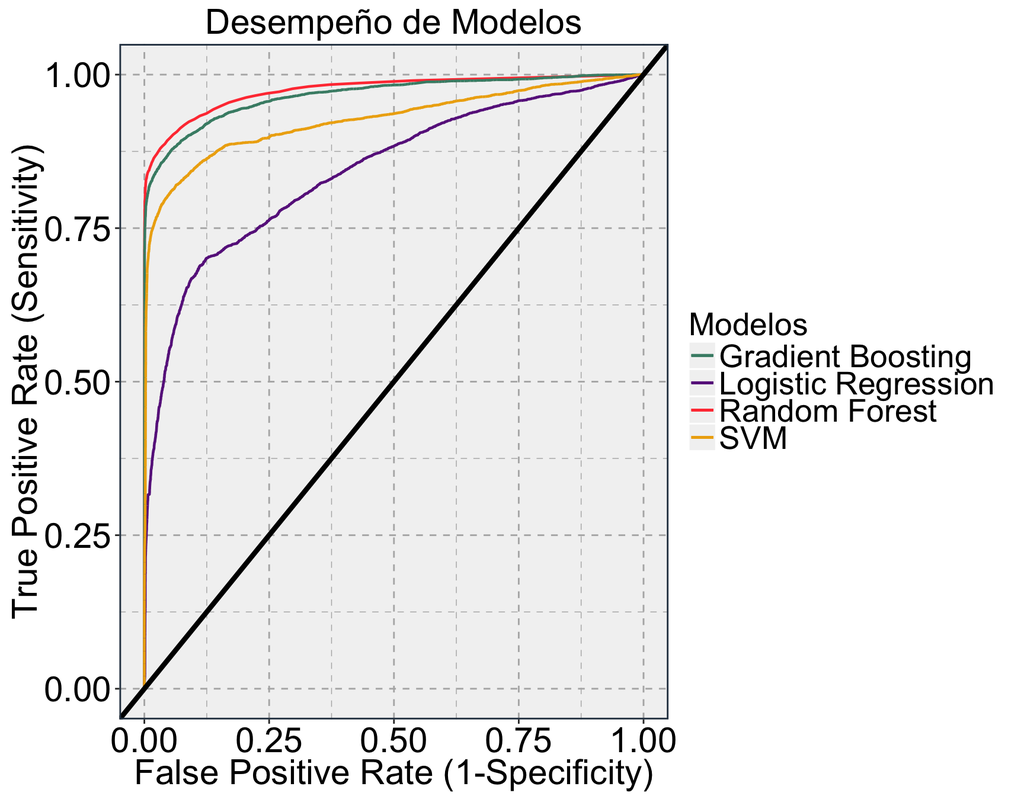